# BAN - 502 Logisitic Regression Classification

## Khayrayyah Haamid-Day

```r
#Task 1
parole = parole %>% mutate(male = as_factor(male)) %>%
  mutate(race = as_factor(race)) %>%
  mutate(state = as_factor(state)) %>%
  mutate(crime = as_factor(crime)) %>%
  mutate(multiple.offenses = as_factor(multiple.offenses)) %>%
  mutate(violator = as_factor(violator))

parole = parole %>% mutate(male = fct_recode(male, "Male" = "1", "Female" = "0" )) %>%
  mutate(race = fct_recode(race, "White" = "1", "Other" = "2")) %>%
  mutate(state = fct_recode(state, "Kentucky" = "2", "Louisiana" = "3", "Virginia" = "4", "Other" = "1")) %>%
  mutate(crime = fct_recode(crime, "Larceny" = "2", "Drug-Related" = "3", "Driving-Related" = "4", "Other" = "1")) %>%
  mutate(multiple.offenses = fct_recode(multiple.offenses, "Yes" = "1", "No" = "0" )) %>%
  mutate(violator = fct_recode(violator, "Yes" = "1", "No" = "2"))
summary(parole)
```

```
##      male        race          age              state      time.served
##  Female:130   White:389   Min.   :18.40   Other    :143   Min.   :0.000
##  Male  :545   Other:286   1st Qu.:25.35   Kentucky :120   1st Qu.:3.250
##                           Median :33.70   Louisiana: 82   Median :4.400
##                           Mean   :34.51   Virginia :330   Mean   :4.198
##                           3rd Qu.:42.55                   3rd Qu.:5.200
##                           Max.   :67.00                   Max.   :6.000
##   max.sentence   multiple.offenses             crime     violator
##  Min.   : 1.00   No :313           Other          :315   0  :597
##  1st Qu.:12.00   Yes:362           Larceny        :106   Yes: 78
##  Median :12.00                     Drug-Related   :153
##  Mean   :13.06                     Driving-Related:101
##  3rd Qu.:15.00
##  Max.   :18.00
```

```r
#Task 2
set.seed(12345)
parole_split = initial_split(parole, prop = 0.70, strata = violator)
train = training(parole_split)
test = testing(parole_split)

t2 = table(parole$violator,parole$male)
prop.table(t2, margin = 2)
```

```
##
##          Female      Male
##   0   0.8923077 0.8825688
##   Yes 0.1076923 0.1174312
```

```r
t3 = table(parole$violator,parole$race)
prop.table(t3, margin = 2)
```

```
##
##            White      Other
##   0   0.90488432 0.85664336
##   Yes 0.09511568 0.14335664
```

```r
t4 = table(parole$violator,parole$state)
prop.table(t4, margin = 2)
```

```
##
##            Other   Kentucky  Louisiana   Virginia
##   0   0.86013986 0.88333333 0.54878049 0.97878788
##   Yes 0.13986014 0.11666667 0.45121951 0.02121212
```

```r
t5 = table(parole$violator,parole$multiple.offenses)
prop.table(t5, margin = 2)
```

```
##
##              No       Yes
##   0   0.9201278 0.8535912
##   Yes 0.0798722 0.1464088
```

```r
t6 = table(parole$violator,parole$crime)
prop.table(t6, margin = 2)
```

```
##
##            Other    Larceny Drug-Related Driving-Related
##   0   0.87619048 0.87735849   0.87581699      0.93069307
##   Yes 0.12380952 0.12264151   0.12418301      0.06930693
```

It appears that a lot of these predictors would indicate that a parolee would not violate their parole if they were, for example, a white female in Virginia but may be more likely to violate their parole if they were in Louisiana instead. Other predictors like having committed multiple offenses and the crime committed being anything other than driving related may increase the likelihood of the parolee violating their parole.

```r
parole_model =
  logistic_reg(mode = "classification") %>% #note the use of logistic_reg and mode = "classification"
  set_engine("glm") #standard logistic regression engine is glm

parole_recipe = recipe(violator ~ state, train) %>%
   step_dummy(all_nominal(), -all_outcomes())

logreg_wf = workflow() %>%
  add_recipe(parole_recipe) %>%
  add_model(parole_model)

parole_fit1 = fit(logreg_wf, train)

summary(parole_fit1$fit$fit$fit)
```

```
##
## Call:
## stats::glm(formula = ..y ~ ., family = stats::binomial, data = data)
##
## Deviance Residuals:
##     Min       1Q   Median       3Q      Max
## -1.0335  -0.5403  -0.2065  -0.2065   2.7780
##
## Coefficients:
##                 Estimate Std. Error z value Pr(>|z|)
## (Intercept)     -1.75539    0.28944  -6.065 1.32e-09 ***
## state_Kentucky  -0.09521    0.43471  -0.219 0.826636
## state_Louisiana  1.40709    0.39351   3.576 0.000349 ***
## state_Virginia  -2.08191    0.53672  -3.879 0.000105 ***
## ---
## Signif. codes:  0 '***' 0.001 '**' 0.01 '*' 0.05 '.' 0.1 ' ' 1
##
## (Dispersion parameter for binomial family taken to be 1)
##
##     Null deviance: 335.47  on 470  degrees of freedom
## Residual deviance: 270.95  on 467  degrees of freedom
## AIC: 278.95
##
## Number of Fisher Scoring iterations: 6
```

This model looks pretty good, the AIC is low, p-values for Louisiana and Virginia are significant. The relationships I saw from the table are similar.

```r
#Task 4
parole_model =
  logistic_reg(mode = "classification") %>%
  set_engine("glm")

parole_recipe = recipe(violator ~ multiple.offenses, train) %>%
   step_dummy(all_nominal(), -all_outcomes())

logreg_wf = workflow() %>%
  add_recipe(parole_recipe) %>%
  add_model(parole_model)

parole_fit2 = fit(logreg_wf, train)

parole_model =
  logistic_reg(mode = "classification") %>%
  set_engine("glm")

parole_recipe = recipe(violator ~ crime, train)

logreg_wf = workflow() %>%
  add_recipe(parole_recipe) %>%
  add_model(parole_model)

parole_fit3 = fit(logreg_wf, train)

summary(parole_fit2$fit$fit$fit)
```

```
##
## Call:
## stats::glm(formula = ..y ~ ., family = stats::binomial, data = data)
##
## Deviance Residuals:
##     Min       1Q   Median       3Q      Max
## -0.5541  -0.5541  -0.4099  -0.4099   2.2444
##
## Coefficients:
##                       Estimate Std. Error z value Pr(>|z|)
## (Intercept)            -2.4346     0.2529  -9.625   <2e-16 ***
## multiple.offenses_Yes   0.6384     0.3090   2.066   0.0388 *
## ---
## Signif. codes:  0 '***' 0.001 '**' 0.01 '*' 0.05 '.' 0.1 ' ' 1
##
## (Dispersion parameter for binomial family taken to be 1)
##
##     Null deviance: 335.47  on 470  degrees of freedom
## Residual deviance: 330.97  on 469  degrees of freedom
## AIC: 334.97
##
## Number of Fisher Scoring iterations: 5
```

```r
summary(parole_fit3$fit$fit$fit)
```

```
##
## Call:
## stats::glm(formula = ..y ~ ., family = stats::binomial, data = data)
##
## Deviance Residuals:
##     Min       1Q   Median       3Q      Max
## -0.5640  -0.5095  -0.5095  -0.4783   2.4802
##
## Coefficients:
##                      Estimate Std. Error z value Pr(>|z|)
## (Intercept)           -1.9761     0.2017  -9.799   <2e-16 ***
## crimeLarceny          -0.1342     0.4252  -0.315    0.752
## crimeDrug-Related      0.2182     0.3447   0.633    0.527
## crimeDriving-Related  -1.0525     0.6245  -1.685    0.092 .
## ---
## Signif. codes:  0 '***' 0.001 '**' 0.01 '*' 0.05 '.' 0.1 ' ' 1
##
## (Dispersion parameter for binomial family taken to be 1)
##
##     Null deviance: 335.47  on 470  degrees of freedom
## Residual deviance: 330.57  on 467  degrees of freedom
## AIC: 338.57
##
## Number of Fisher Scoring iterations: 5
```

**Task 4** I chose to look at these two predictors as they had some probabilities that were similar to those found in the state predictor. Compared to the first model I created, the AIC is higher on these models and there is no significance for crime variables.There is small significance for multiple offenses.

```r
#Task5
parole_model =
  logistic_reg(mode = "classification") %>%
  set_engine("glm")

parole_recipe = recipe(violator ~ state + multiple.offenses + race, train) %>%
   step_dummy(all_nominal(), -all_outcomes())

logreg_wf = workflow() %>%
  add_recipe(parole_recipe) %>%
  add_model(parole_model)

parole_fit4 = fit(logreg_wf, train)

summary(parole_fit4$fit$fit$fit)
```

```
##
## Call:
## stats::glm(formula = ..y ~ ., family = stats::binomial, data = data)
##
## Deviance Residuals:
##     Min       1Q   Median       3Q      Max
## -1.3572  -0.4013  -0.2705  -0.1557   2.9726
##
## Coefficients:
##                       Estimate Std. Error z value Pr(>|z|)
## (Intercept)           -2.47873    0.36085  -6.869 6.46e-12 ***
## state_Kentucky        -0.01418    0.46926  -0.030  0.97590
## state_Louisiana        0.11876    0.49950   0.238  0.81206
## state_Virginia        -3.58422    0.63848  -5.614 1.98e-08 ***
## multiple.offenses_Yes  1.65689    0.39652   4.179 2.93e-05 ***
## race_Other             1.11646    0.39092   2.856  0.00429 **
## ---
## Signif. codes:  0 '***' 0.001 '**' 0.01 '*' 0.05 '.' 0.1 ' ' 1
##
## (Dispersion parameter for binomial family taken to be 1)
##
##     Null deviance: 335.47  on 470  degrees of freedom
## Residual deviance: 244.52  on 465  degrees of freedom
## AIC: 256.52
##
## Number of Fisher Scoring iterations: 6
```

**Task 5**

The AIC on this model is the lowest compared to the others. The variables Virginia, multiple offenses, and race have significance. Louisiana does not have significance in this model.

```r
#Task 6
newdata = data.frame(state = "Louisiana", multiple.offenses = "Yes", race = "White")
predictions = predict(parole_fit4, newdata, type="prob")[2]
head(predictions)
```

```
## # A tibble: 1 x 1
##   .pred_Yes
##       <dbl>
## 1     0.331
```

```r
#Task 6
newdata = data.frame(state = "Kentucky", multiple.offenses = "No", race = "Other")
predictions = predict(parole_fit4, newdata, type="prob")[2]
head(predictions)
```

```
## # A tibble: 1 x 1
##   .pred_Yes
##       <dbl>
## 1     0.202
```

**Task 6**

Parole 1 has a predicted probability of .33 of violating their parole while Parole 2 has a probability of .20 of violating their parole.

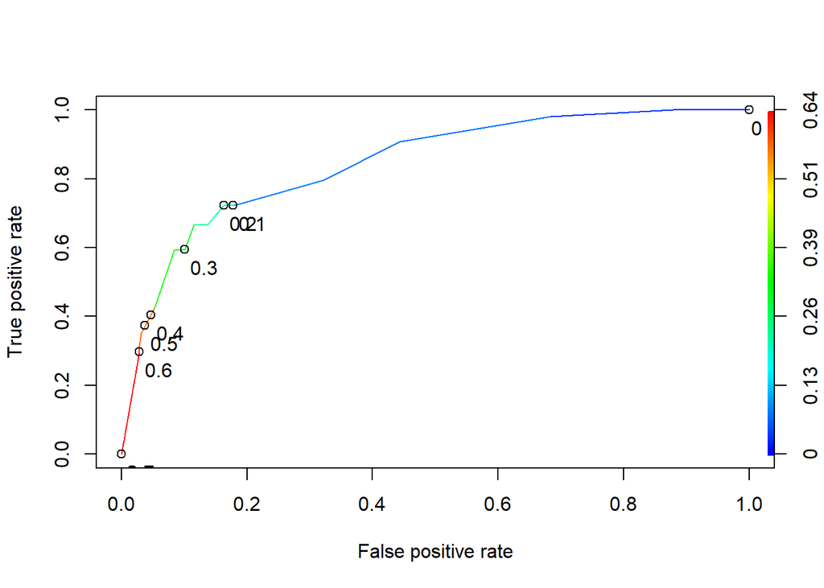

```r
#Task 7
predictions1 = predict(parole_fit4, train, type="prob")[2]

ROCRpred = prediction(predictions1, train$violator)

ROCRperf = performance(ROCRpred, "tpr", "fpr")
plot(ROCRperf, colorize=TRUE, print.cutoffs.at=seq(0,1,by=0.1), text.adj=c(-0.2,1.7))
```

```r
#Sensitivity and specificity
opt.cut = function(perf, pred){
    cut.ind = mapply(FUN=function(x, y, p){
        d = (x - 0)^2 + (y-1)^2
        ind = which(d == min(d))
        c(sensitivity = y[[ind]], specificity = 1-x[[ind]],
            cutoff = p[[ind]])
    }, perf@x.values, perf@y.values, pred@cutoffs)
}
print(opt.cut(ROCRperf, ROCRpred))
```

```
##                  [,1]
## sensitivity 0.7222222
## specificity 0.8369305
## cutoff      0.2015788
```

```r
# Accuracy
t1 = table(train$violator,predictions1 >  0.08627651)
t1
```

```
##
##       FALSE TRUE
##   0     349   68
##   Yes    15   39
```

```r
(t1[1,1]+t1[2,2])/nrow(train)
```

```
## [1] 0.8237792
```

**Task 7**

The accuracy is .82, the sensitivity is .72, the specificity is .83. The implication of incorrectly classifying a parolee is its impact on accuracy; for example, a high accuracy could have you believing that parolees are not likely to violate their parole when this may not be true in reality.

```r
#Task 9
t1 = table(train$violator,predictions1 > 0.3)
t1
```

```
##
##       FALSE TRUE
##   0     375   42
##   Yes    22   32
```

```r
(t1[1,1]+t1[2,2])/nrow(train)
```

```
## [1] 0.8641189
```

```r
t2 = table(train$violator,predictions1 > 0.5)
t2
```

```
##
##       FALSE TRUE
##   0     404   13
##   Yes    35   19
```

```r
(t2[1,1]+t2[2,2])/nrow(train)
```

```
## [1] 0.8980892
```

```r
t3 = table(train$violator,predictions1 > 0.6)
t3
```

```
##
##       FALSE TRUE
##   0     405   12
##   Yes    38   16
```

```r
(t3[1,1]+t3[2,2])/nrow(train)
```

```
## [1] 0.8938429
```

```r
# Task 10
predictions2 =  predict(parole_fit4, test, type="prob")[2]
t4 = table(test$violator,predictions2 > 0.5)
t4
```

```
##
##       FALSE TRUE
##   0     175    5
##   Yes    16    8
```

```r
(t4[1,1]+t4[2,2])/nrow(test)
```

```
## [1] 0.8970588
```